# Juniper Health Plan: Follow-Along

ASC Workshop · Healthcare Analytics

Author

**How to use this file**

Run each cell from top to bottom (in Positron, VS Code, or `quarto preview`). Cells marked **🧩 Your Turn** are yours to fill in. Every value in `data/` is **fictitious**.

# 0. Setup

```python
import numpy as np
import pandas as pd
import statsmodels.api as sm
import statsmodels.formula.api as smf
from plotnine import *

theme_set(theme_minimal(base_size=12) + theme(figure_size=(7, 4)))
```

```python
claims  = pd.read_csv("data/claims.csv", parse_dates=["service_date"])
members = pd.read_csv("data/members.csv", parse_dates=["enroll_start", "enroll_end"])
ehr     = pd.read_csv("data/ehr_encounters.csv", parse_dates=["encounter_date"])
xwalk   = pd.read_csv("data/mrn_crosswalk.csv")
census  = pd.read_csv("data/census_zip.csv", dtype={"zip": str})
vendor  = pd.read_csv("data/vendor_sdoh.csv")

members["zip"] = members["zip"].astype(str)
members["age"] = 2025 - members["birth_year"]
```

Take a quick look at each table. What is **one row** in each?

```python
claims.head()
```

|  | claim_id | member_id | service_date | claim_type | place_of_service | dx1 | procedure_or_drug | allowed_amt | paid_amt | claim_status |
| --- | --- | --- | --- | --- | --- | --- | --- | --- | --- | --- |
| 0 | C2000000 | M100034 | 2025-01-01 | professional | 02 Telehealth | E11.9 | 99213 | 144.85 | 111.38 | paid |
| 1 | C2000001 | M100075 | 2025-01-01 | professional | 02 Telehealth | R51.9 | 99213 | 112.42 | 94.49 | paid |
| 2 | C2000002 | M100089 | 2025-01-01 | professional | 11 Office | M54.50 | 99213 | 121.33 | 114.33 | paid |
| 3 | C2000003 | M100125 | 2025-01-01 | professional | 02 Telehealth | J06.9 | 99214 | 148.63 | 121.93 | paid |
| 4 | C2000004 | M100191 | 2025-01-01 | pharmacy | Pharmacy | NaN | metformin | 12.57 | 8.86 | paid |

```python
members.head()
```

|  | member_id | zip | plan_type | birth_year | sex | enroll_start | enroll_end | member_months | age |
| --- | --- | --- | --- | --- | --- | --- | --- | --- | --- |
| 0 | M100000 | 84119 | Commercial | 1991 | F | 2025-01-01 | 2025-12-31 | 12 | 34 |
| 1 | M100001 | 84101 | Medicare Advantage | 1937 | M | 2025-07-01 | 2025-12-31 | 6 | 88 |
| 2 | M100002 | 84321 | Commercial | 1995 | F | 2025-01-01 | 2025-12-31 | 12 | 30 |
| 3 | M100003 | 84601 | Medicaid | 2015 | F | 2025-01-01 | 2025-12-31 | 12 | 10 |
| 4 | M100004 | 84111 | Medicaid | 1969 | F | 2025-01-01 | 2025-12-31 | 12 | 56 |

# 1. Claims

## Net out reversals

Some claims were reversed (negative dollars). Sum each claim before doing anything else.

```python
claims["claim_status"].value_counts()
```

```
claim_status
paid        27535
reversed      413
Name: count, dtype: int64
```

```python
net = (claims.groupby(["claim_id", "member_id", "service_date", "claim_type",
                       "place_of_service", "dx1", "procedure_or_drug"], dropna=False)
             [["allowed_amt", "paid_amt"]].sum().reset_index())
net = net[net["paid_amt"] > 0]
len(claims), len(net)
```

```
(27948, 27122)
```

## PMPM by plan type

```python
paid = net.groupby("member_id")["paid_amt"].sum()
mem = members.assign(paid=members["member_id"].map(paid).fillna(0))

pmpm = mem.groupby("plan_type")[["paid", "member_months"]].sum()
pmpm["pmpm"] = pmpm["paid"] / pmpm["member_months"]
pmpm.round(0)
```

| plan_type | paid | member_months | pmpm |
| --- | --- | --- | --- |
| Commercial | 2920267.0 | 19367 | 151.0 |
| Medicaid | 1254390.0 | 6866 | 183.0 |
| Medicare Advantage | 1941453.0 | 6201 | 313.0 |

## How concentrated is spending?

```python
spend = mem.sort_values("paid", ascending=False)["paid"]
top5 = spend.head(int(len(spend) * 0.05)).sum() / spend.sum()
print(f"Top 5% of members = {top5:.0%} of spend")
```

```
Top 5% of members = 43% of spend
```

## ED visits

We’ll reuse `ed` (all ED claims) for the rest of the workshop.

```python
ed = net[net["place_of_service"].str.startswith("23")]
rx = net[net["claim_type"] == "pharmacy"]
ed.shape, rx.shape
```

```
((873, 9), (15540, 9))
```

## 🧩 Your Turn: Claims

1. Which **diagnosis codes** (`dx1`) show up most in ED visits?
2. What share of pharmacy dollars goes to **GLP-1 RA**? How many members fill one?

**Hints**

- `ed["dx1"].value_counts()`
- Group `rx` by `procedure_or_drug`, sum `paid_amt`, and divide by the total.
- `.nunique()` counts unique members.

```python
# 1. Top ED diagnosis codes


# 2. GLP-1 share of pharmacy $ and number of members
```

# 2. Electronic Health Records

## Link EHR to members

```python
ehr_m = ehr.merge(xwalk, on="mrn", how="left")
print(f"{members['member_id'].isin(ehr_m['member_id']).mean():.0%} of members have EHR data")
```

```
62% of members have EHR data
```

## Clean impossible BMIs

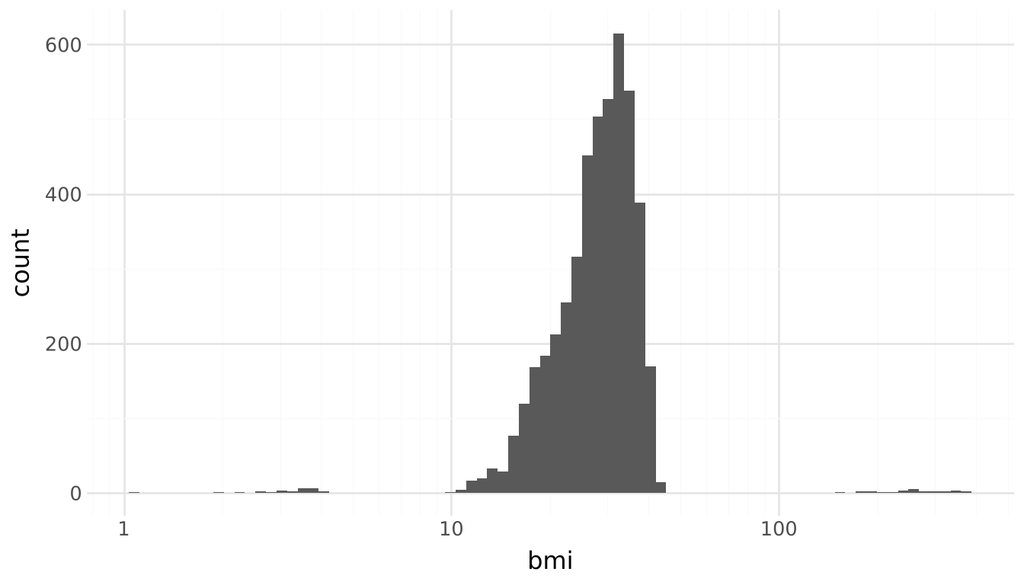

```python
(ggplot(ehr_m.dropna(subset=["bmi"]), aes("bmi"))
 + geom_histogram(bins=80) + scale_x_log10())
```

```python
ehr_m.loc[~ehr_m["bmi"].between(12, 70), "bmi"] = np.nan
```

## Who has diabetes? Three sources

```python
dx  = set(net.loc[net["dx1"] == "E11.9", "member_id"])                 # diagnosis (claims)
rxd = set(net.loc[net["procedure_or_drug"] == "metformin", "member_id"])  # drug (claims)
lab = set(ehr_m.loc[ehr_m["a1c"] >= 6.5, "member_id"])                # lab (EHR)

# Among EHR-linked members: which sources flag them?
src = pd.DataFrame({"member_id": ehr_m["member_id"].unique()})
src["Dx"], src["Rx"], src["Lab"] = [src["member_id"].isin(s) for s in (dx, rxd, lab)]
src.query("Dx or Rx or Lab").value_counts(["Dx", "Rx", "Lab"])
```

```
Dx     Rx     Lab
True   True   True     186
False  True   True      83
True   True   False      3
False  True   False      2
       False  True       1
True   False  True       1
Name: count, dtype: int64
```

## 🧩 Your Turn: EHR

Use each member’s **highest PHQ-9** to assign depression severity (0–4 none/minimal, 5–9 mild, 10–14 moderate, 15–19 mod-severe, 20+ severe). How many with PHQ-9 ≥ 10 have **no** depression diagnosis (`F32*` or `F33*`) in claims?

**Hints**

- `ehr_m.groupby("member_id")["phq9"].max()`
- `pd.cut(x, bins=[-1, 4, 9, 14, 19, 27], labels=[...])`
- `net["dx1"].str.match(r"F3[23]", na=False)` finds depression codes.

```python
# Highest PHQ-9 per member


# Severity categories


# PHQ-9 >= 10 with no depression diagnosis
```

# 3. Public / Census Data

```python
census.head()
```

|  | zip | county | svi | median_hh_income | pct_poverty | pct_uninsured | pct_age65plus | population |
| --- | --- | --- | --- | --- | --- | --- | --- | --- |
| 0 | 84321 | Cache | 0.42 | 71600 | 13.1 | 8.7 | 20.6 | 31990 |
| 1 | 84341 | Cache | 0.22 | 90800 | 8.7 | 7.5 | 12.5 | 40696 |
| 2 | 84302 | Box Elder | 0.55 | 57000 | 16.3 | 8.9 | 17.7 | 10767 |
| 3 | 84401 | Weber | 0.78 | 57400 | 20.2 | 13.7 | 12.4 | 27979 |
| 4 | 84041 | Davis | 0.30 | 87200 | 10.0 | 5.4 | 11.7 | 27296 |

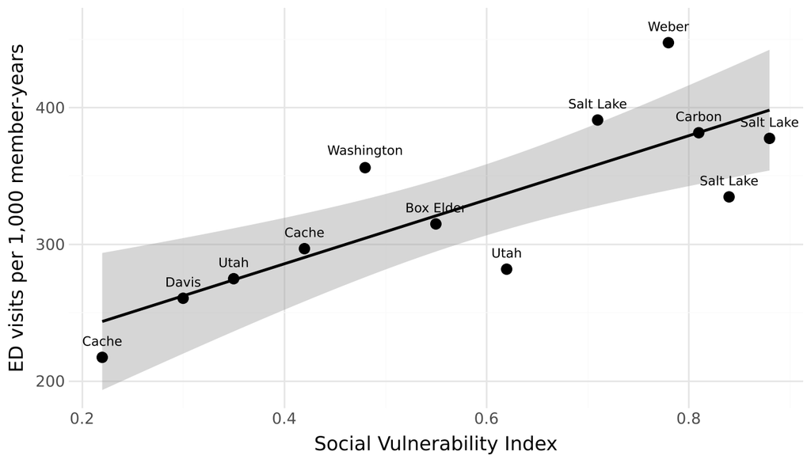

```python
ed_n = ed.groupby("member_id").size().rename("ed_visits")
by_zip = (mem.merge(ed_n, on="member_id", how="left").fillna({"ed_visits": 0})
             .groupby("zip")[["ed_visits", "member_months"]].sum()
             .merge(census, on="zip"))
by_zip["ed_per_1000"] = 12_000 * by_zip["ed_visits"] / by_zip["member_months"]

(ggplot(by_zip, aes("svi", "ed_per_1000"))
 + geom_smooth(method="lm") + geom_point(size=3)
 + geom_text(aes(label="county"), nudge_y=12, size=8)
 + labs(x="Social Vulnerability Index", y="ED visits per 1,000 member-years"))
```

**Note to self:** what does the ecological fallacy warn us about here?

# 4. Vendor Data

```python
v = members[["member_id"]].merge(vendor, on="member_id", how="left")
print(f"Matched: {v['match_confidence'].notna().mean():.0%}  |  "
      f"High-confidence (>= 0.7): {(v['match_confidence'] >= 0.7).mean():.0%}")
```

```
Matched: 83%  |  High-confidence (>= 0.7): 67%
```

```python
dat = (mem.merge(ed_n, on="member_id", how="left").fillna({"ed_visits": 0})
          .merge(census, on="zip")
          .merge(vendor, on="member_id")
          .query("match_confidence >= 0.7"))
dat["diabetes_dx"] = dat["member_id"].isin(dx).astype(int)

fit = smf.glm("ed_visits ~ food_insecurity_index + svi + age + diabetes_dx + C(plan_type)",
              data=dat, family=sm.families.Poisson(),
              offset=np.log(dat["member_months"])).fit()
np.exp(fit.params).round(3)    # incidence rate ratios (IRRs)
```

```
Intercept                             0.009
C(plan_type)[T.Medicaid]              1.427
C(plan_type)[T.Medicare Advantage]    1.280
food_insecurity_index                 1.013
svi                                   0.954
age                                   1.003
diabetes_dx                           1.392
dtype: float64
```

## 🧩 Your Turn: Vendor + Model

1. Add `housing_instability` and `transportation_barrier` to the model. Do they matter after food insecurity?
2. Refit using **all** matched members (drop the confidence filter). Does the food-insecurity IRR change?

**Hints**

- Copy the `smf.glm(...)` call and add terms with `+`.
- `fit.conf_int()` gives confidence intervals; exponentiate them too.
- For #2, rebuild `dat` without the `.query(...)` line.

```python
# 1. Add housing & transportation


# 2. No confidence filter
```

# Going Further

- Which **ZIP** has the highest PMPM? Does it line up with SVI?
- Are high-cost members (top 5%) more likely to have a **diabetes** diagnosis?
- Rerun the depression exercise using **only claims**. How many people would you miss?